# Project 5: Using Neo4J to Represent Related Diseases from PubMed-Scrapped Data

Mauricio Alarcon

May 3, 2015

# Summary

The purpose of this project is to build a graph database of diseases and other related diseases by scraping a well-known clinical-literature search engine such as [PubMed](http://www.ncbi.nlm.nih.gov/pubmed).

The assumption is that if a publication contains references to conditions A and B, there may be a relationship between these two. If the above it is true for a large number of publications, it may suggest that the disease combination could be a good candidate for further analysis.

We will use disease terms found in ICD9 classification data.

The goal is to obtain frequency counts of: * Individual disease terms: Diabetes, Cancer, HIV, etc. * All disease terms combinations: Diabetes AND Cancer, Diabetes AND HIV, etc.

# The Libraries

```r
library(RCurl)
library(XML)
library(rvest)
library(knitr)
library(plyr)
library(stringr)
library(rmongodb)
library(rjson)
library(tm)
```

# Loading Diesease Phrases

The Healthcare Utilization Project (HCUP) has an ICD9 classification data available in [their website](https://www.hcup-us.ahrq.gov/toolssoftware/ccs/ccs.jsp).

There is one file in particular that contains diagnosis category names. This list is great as the disease labels are in [plain english](https://www.hcup-us.ahrq.gov/toolssoftware/ccs/CCSCategoryNames_FullLabels.pdf).

A CSV version of this file is available in the [Single-Level Diagnosis CCS Categories](https://www.hcup-us.ahrq.gov/toolssoftware/ccs/Single_Level_CCS_2015.zip). This is the data that we will use as our list of diseases.

```r
# get files diagnosis category label from CSV in github
dxref <- "https://raw.githubusercontent.com/rmalarc/is607/master/final_project/Single_Level_CCS_2015/dxlabel%202013.csv"
dxref_data_csv <- getURL(dxref)
dxref_data <- read.csv(text=dxref_data_csv,head=TRUE,sep=",",as.is=TRUE)

#clean up column names and turn to lower_case
colnames(dxref_data)<-tolower(gsub("\\.","_",colnames(dxref_data)))

kable(summary(dxref_data))
```

|  | ccs_diagnosis_categories | ccs_diagnosis_categories_labels |
| --- | --- | --- |
|  | Length:288 | Length:288 |
|  | Class :character | Class :character |
|  | Mode :character | Mode :character |

```r
kable(head(dxref_data,n=25))
```

| ccs_diagnosis_categories | ccs_diagnosis_categories_labels |
| --- | --- |
| .Z | Overall |
| . | No diagnosis |
| .A | Invalid diagnosis |
| 1 | Tuberculosis |
| 2 | Septicemia (except in labor) |
| 3 | Bacterial infection; unspecified site |
| 4 | Mycoses |
| 5 | HIV infection |
| 6 | Hepatitis |
| 7 | Viral infection |
| 8 | Other infections; including parasitic |
| 9 | Sexually transmitted infections (not HIV or hepatitis) |
| 10 | Immunizations and screening for infectious disease |
| 11 | Cancer of head and neck |
| 12 | Cancer of esophagus |
| 13 | Cancer of stomach |
| 14 | Cancer of colon |
| 15 | Cancer of rectum and anus |
| 16 | Cancer of liver and intrahepatic bile duct |
| 17 | Cancer of pancreas |
| 18 | Cancer of other GI organs; peritoneum |
| 19 | Cancer of bronchus; lung |
| 20 | Cancer; other respiratory and intrathoracic |
| 21 | Cancer of bone and connective tissue |
| 22 | Melanomas of skin |

# Preparing the Disease Terms

In order to use the disease terms we need to:

- Clean up strings (remove numbers, punctuation, convert to lower-case)
- Remove stop words
- URL Encode the phrases

```r
# flag those terms that appear to be invalid
dxref_data$is_valid <- TRUE
dxref_data[dxref_data$ccs_diagnosis_categories %in%
             c(".Z  ",".   ",".A  ","254","255","256","257","258","259","41"),"is_valid"] <-FALSE
dxref_data[grep("E Codes: ",dxref_data$ccs_diagnosis_categories_labels),"is_valid"] <-FALSE

# gsub helper function
toString <- content_transformer(function(x, from, to) gsub(from, to, x))

#load data into corpus
dxref_data_corpus <- Corpus(VectorSource(dxref_data[2]))

#remove numbers
dxref_data_corpus <- tm_map(dxref_data_corpus, removeNumbers)

# to lowercase
dxref_data_corpus <- tm_map(dxref_data_corpus, content_transformer(tolower))

# Hyphens to spaces
dxref_data_corpus <- tm_map(dxref_data_corpus, toString, "-", " ")

# remove the stuff in parentesis
dxref_data_corpus <- tm_map(dxref_data_corpus, toString, "\\(.+\\)", "")

# replace / or - for whitespace
dxref_data_corpus <- tm_map(dxref_data_corpus, toString, "(/|-)", " ")

#remove punctuation
dxref_data_corpus <- tm_map(dxref_data_corpus, removePunctuation)


# remove english stop words
dxref_data_corpus <- tm_map(dxref_data_corpus, removeWords, stopwords("english"))

# remove english stop words
dxref_data_corpus <- tm_map(dxref_data_corpus, removeWords, c("unspecified","site","primary"))

# strip double white spaces
dxref_data_corpus <- tm_map(dxref_data_corpus, toString, "^\\s+|\\s+$", "")
dxref_data_corpus <- tm_map(dxref_data_corpus, toString, "  ", " ")
dxref_data_corpus <- tm_map(dxref_data_corpus, stripWhitespace)

# merge with dataframe
dxref_data$disease_phrase <- dxref_data_corpus[["1"]][["content"]]
dxref_data$disease_phrase <- gsub(" "," AND ",dxref_data$disease_phrase)
dxref_data$url_params <- sapply(dxref_data$disease_phrase,URLencode)
```

# Helper Functions

In order to facilitate scraping more than one page, we will use the following functions:

```r
####################################################################################
# pubmed_entries_for(URLParams)
#
# This function scrapes pubmed by searching for the specified URL encoded keyword.
# The function returns the number of entries in pubmed for the keyword.
####################################################################################

pubmed_esearch_entry <-function(URLParams) {
  #URLParams <- "sexually%20AND%20transmitted%20AND%20infections"
  Sys.sleep(0.2)
  baseURL <- "http://eutils.ncbi.nlm.nih.gov/entrez/eutils/esearch.fcgi?db=pubmed&retmax=500000&retmode=xml&term="
  theURL <- paste(baseURL,URLParams,sep="")
  page_data <- xmlParse(theURL)

  # get the number of pubmed hits
  Count<- page_data %>%
              xml_nodes("eSearchResult") %>%
              xml_node("Count")
  Count<-as.integer(sapply(Count,xmlValue))

  # get the number of pubmed hits
  RetMax<- page_data %>%
              xml_nodes("eSearchResult") %>%
              xml_node("RetMax")
  RetMax<-as.integer(sapply(RetMax,xmlValue))


#  list<-xmlToList(page_data)

  IdList<- page_data %>%
              xml_nodes("eSearchResult") %>%
              xml_node("IdList") %>%
              xml_nodes("Id")
  IdList<- data.frame(as.integer(sapply(IdList,xmlValue)))
  colnames(IdList) = "Id"


  retval <- list(url_params=URLParams
                 ,Count=Count
                ,RetMax=RetMax
                 ,IdList=IdList)
  return(retval)
}

####################################################################################
# pubmed_esearch_entries(ref_data, entry_type)
#
# This function accepts a dataframe containing the entries to process as well as an entry_type.
# The DF must contain a column called url_params, which are the URL parameters passed to
# pubmed_entries_for.
#
# The processed output is saved to MongoDB and returned as a dataframe.
# Two CSV files are generated as well:
#     * [entry_type]_entry.csv: Contains the entry provided in ref_data plust the number
#        of pubmed hits
#     * [entry_type]_entry_docs.csv: Contains all document ids for each of the keywords in
#       ref_data
####################################################################################
pubmed_esearch_entries <- function(ref_data,entry_type) {
  #ref_data<-dxref_data_x_join
  #entry_type<-"intersect_count"
  # BASE PATH
  base_path <-"/Users/malarcon/Google Drive/CUNY/IS607/submissions/project5/"

  coll<-paste(ns,entry_type,sep=".")

  # get previously exported records
  entries_processed <- NULL
  cursor<-mongo.find(m
                     ,coll
                     ,query = mongo.bson.empty()
                     ,fields=list(url_params=1L)
                     )
  entries_processed <- mongo.cursor.to.data.frame(cursor)
  mongo.cursor.destroy(cursor)

  # process records not already processed
  entries_to_process <- ref_data[!(ref_data$url_params %in% entries_processed$url_params),]

  if(nrow(entries_to_process)>0){
    for (i in 1:nrow(entries_to_process)){
      #i<-1
      entry<-entries_to_process[i,]
      # get the number of hits for entry in pubmed
      esearch<-pubmed_esearch_entry(entry$url_params)

      # resulting DF
      results<-split(entry[1,], "Query")
      results$entry_type <- entry_type
      results$esearch<-esearch

      # export keyword details to CSV
      entry <- data.frame(entry,Count=esearch$Count)
      entry_columns <- colnames(entry)
      write.table(entry
                ,file=paste(base_path,entry_type,"_entry.csv",sep="")
                ,append=TRUE
                ,row.names=FALSE
                ,col.names=FALSE
                , sep = ","
                )

      # Write doclist to _entry.csv
      if (esearch$Count >0 ){
        # export document list to CSV
        entry_docs<-data.frame(url_params=entry$url_params,results$esearch$IdList)
        entry_docs_columns <- colnames(entry_docs)
        write.table(entry_docs
                ,file=paste(base_path,entry_type,"_entry_docs.csv",sep="")
                ,append=TRUE
                ,row.names=FALSE
                ,col.names=FALSE
                ,sep = ","
                )
      }
      # export to mongo
      mongo.insert(m, coll,mongo.bson.from.JSON(toJSON(esearch)))
    }
    # export header names
    entry_docs_columns <- paste(colnames(entry_docs),collapse=",")
    write.table(entry_docs_columns
                ,file=paste(base_path,entry_type,"_entry_docs_columns.csv",sep="")
                ,append=TRUE
                ,row.names=FALSE
                ,col.names=FALSE
                , sep = ","
                )

    entry_columns <- paste(colnames(entry),collapse=",")
    write.table(entry_columns
                ,file=paste(base_path,entry_type,"_entry_columns.csv",sep="")
                ,append=TRUE
                ,row.names=FALSE
                ,col.names=FALSE
                , sep = ","
                )
  }

  # get all processed entries
  cursor <- mongo.find(m
                       ,coll
                       ,query = mongo.bson.empty()
                       ,fields=list(url_params=1L,
                                    Count=1L,
                                    RetMax=1L)
                       )
  entries_processed <- mongo.cursor.to.data.frame(cursor)
  mongo.cursor.destroy(cursor)

  return(entries_processed)
}
```

# Scraping the Pubmed Search Engine - Getting Frequency Counts of Individual Disease Terms

```r
# connect to monogo so we can export the results of the scrape a row at a time
m <- mongo.create()
ns <- "esearch_pubmed"


# yes, it's a loop. The apply functions are faster. However, the function gets delayed by a sec
# each time. The loop allows me to restart where I left off
entries_processed <- NULL

# If you want to restart the whole process from scratch, set restart to TRUE
restart <- FALSE
if (restart){
  #delete all previously processed entries by purging the contents of the MongoDB
  mongo.remove(m, ns)
}

absolute_count_entries_processed <- pubmed_esearch_entries(dxref_data[dxref_data$is_valid,],"absolute_count")
# show a sample of the output
#kable(head(absolute_count_entries_processed,n=25))
```

# Loading the Output into Neo4J

This is easier said than done. A [cypher query](https://raw.githubusercontent.com/rmalarc/is607/master/project5/pubmed_to_neo4j.cypher) was written in order to load the CSVs generated in the previous step by using the LOAD CSV WITH cypher command.

After much query tweaking I was only able to load the smaller files. Server crashes and out of memory errors were the main issue I found when trying to load the larger file in this fashion. I found several references alluding to server configuration tweaks and other tricks in order to handle larger files.

In my case however, `absolute_count_entry_docs.csv` contains 8.6M records and is 351Mb in size. I was unable to load it using the LOAD CSV WITH cypher method. I resorted to the [neo4j-import tool](http://neo4j.com/docs/stable/import-tool-basic-example.html) which proved to be an effective method for large files.

The sequence of commands that load the data into a “new” database are:

```
rm -r pubmed_db

neo4j-import --nodes pubmed_docs_columns.csv,pubmed_docs2.csv \
            --nodes absolute_count_entry_columns.csv,absolute_count_entry2.csv \
            --relationships absolute_count_entry_docs_columns.csv,absolute_count_entry_docs2.csv \
            --into pubmed_db
```

# Using the Data in a Graph

## Items Related to a Single Diagnosis

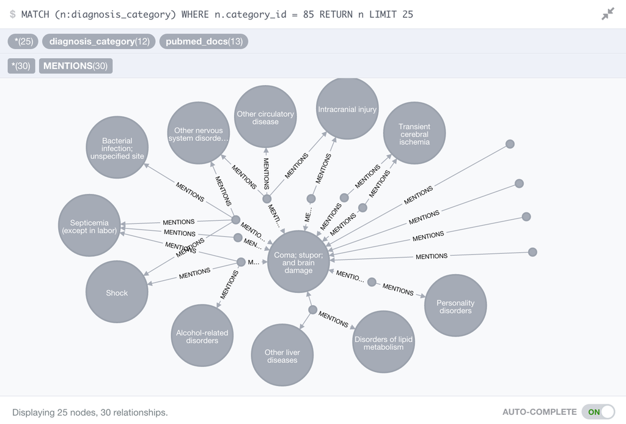

The above output represents a query for the diagnosis category **Coma; stupor; and brain damage**

As we can see from the graph, we can see other potentially related diagnosis as they are also mentioned in the same PubMed documents.

## Most Frequently Published Diagnosis (Top 20)

```
MATCH ()-[r:MENTIONS]->(a)
RETURN a.category_description , count(*) AS frequency
ORDER BY frequency DESC
LIMIT 20
```

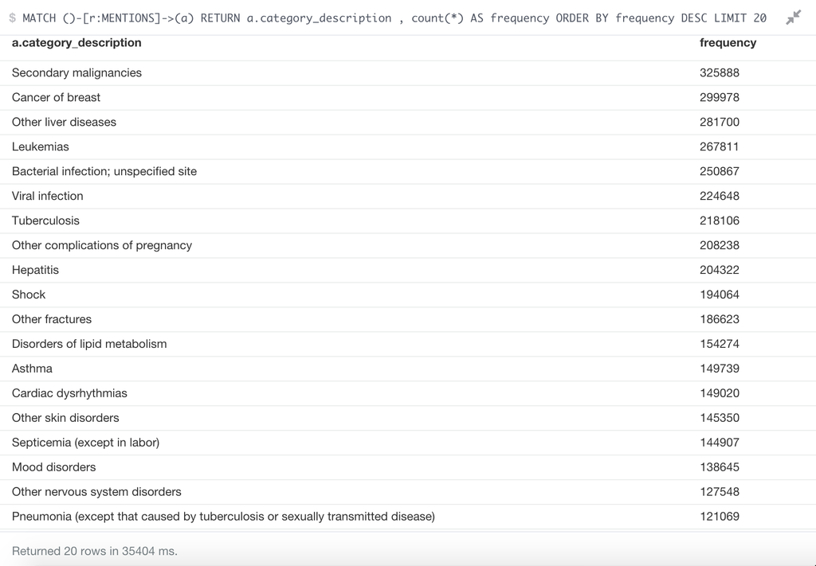

```
MATCH (a)<-[r:MENTIONS]-()-[r1:MENTIONS]->(b)
RETURN a.category_description , b.category_description, count(*) AS frequency
ORDER BY frequency DESC
LIMIT 20
```

[figure not shown]

## Create Inter-Diagnosis Relationships

The goal here is to create a relationship called RELATED. Let’s say that we have papers that mention the diagnostic terms: Cancer of Uterus and Cancer of Cervix. That’s what the RELATED relationship is based on. Note how the relationship is quantified by using the frequency and the probability of that relationship ocurring based on the total number of documents.

I have two basic rules for defining a relationship:

- Given any two diagnosis a and b, there are two relationships, A given B and B given A. The two probabilities are calculated, P(A|B) and P(B|A).
- The frequency count of the relationship ab must be representative. For practical purposes, I’m assuming that any value greater than 200 is statistically representative.

```
CREATE INDEX ON :diagnosis_category(category_id);
CREATE INDEX ON :pubmed_docs(pubmed_id);


MATCH (a)<-[r:MENTIONS]-()-[r1:MENTIONS]->(b)
WITH a
    ,b
    , TOFLOAT(count(*)) AS frequency
WHERE frequency > 200
CREATE (a)
                -[:RELATED {mentions:frequency
                            ,mentions_probability: frequency/a.frequency}]->
                (b);
```

## Get Top-20 Most Related Diagnosis

```
MATCH (a)-[r:RELATED]->(b)
WHERE r.mentions_probability > 0.1
RETURN a.category_description,b.category_description,r.mentions_probability
ORDER BY r.mentions_probability  DESC
LIMIT 20
```

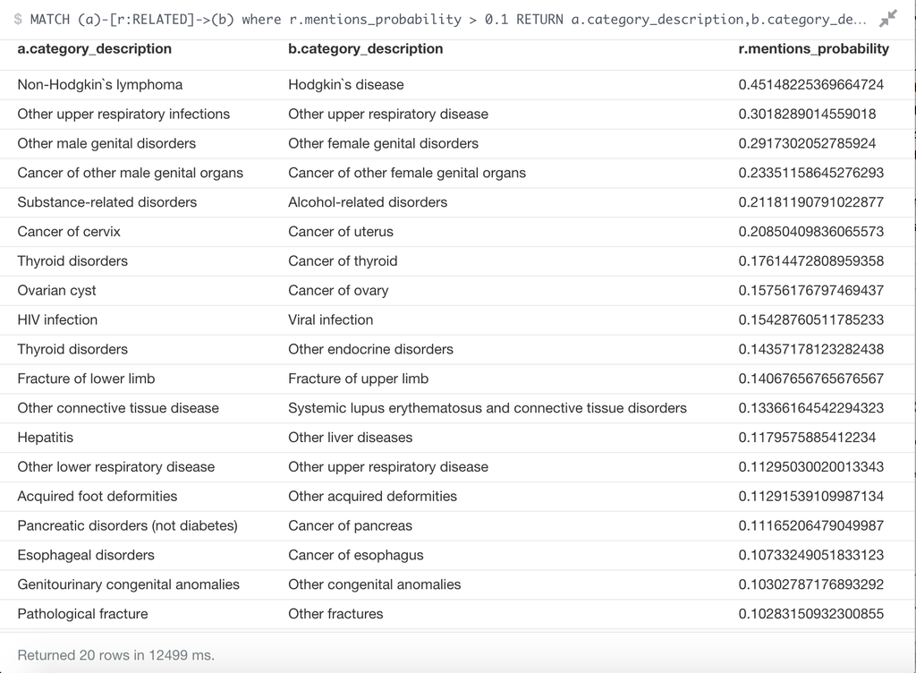

## Get Diagnosis Related by at least 20%

```
CREATE INDEX ON :RELATED(mentions_probability);

MATCH ()-[r:RELATED]->()
WHERE r.mentions_probability > 0.2
RETURN r
```

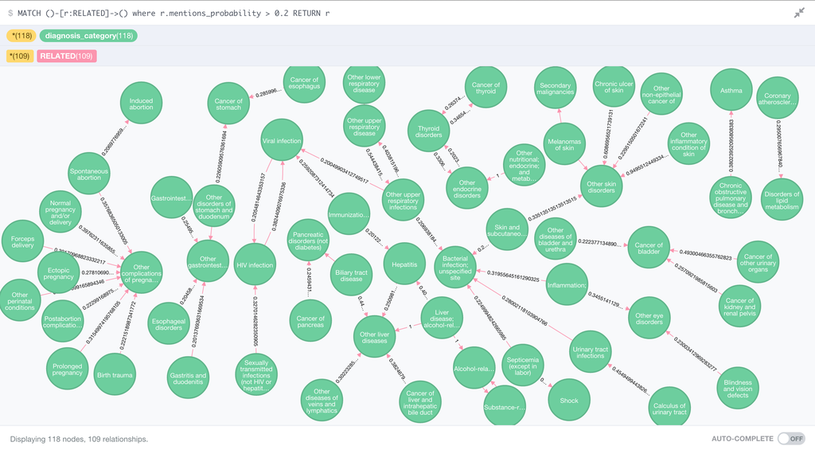

This one I really like and is the whole point of the project. Notice how the graph suggests that there may be a relationship between HIV, Viral Infection, Hepatitis and Liver diseases (which is true).

## Tell me what diagnosis are related to Spinal Cord Injury by at least 5%

```
MATCH (a:diagnosis_category)-[r:RELATED]->(b:diagnosis_category)
WHERE (a.category_id = 227
        OR b.category_id = 227)
      and r.mentions_probability >= 0.05
RETURN r
```

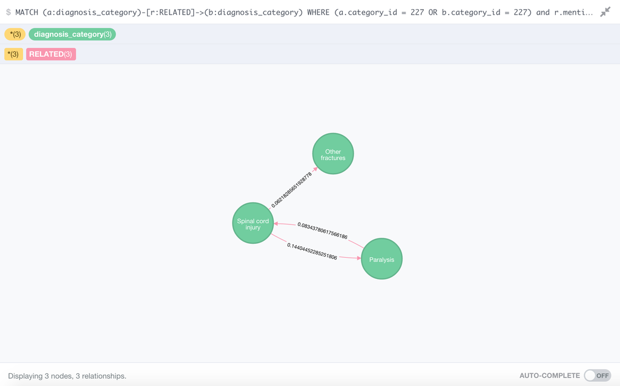